# Univariate Plots Section

[output not shown]

[output not shown]

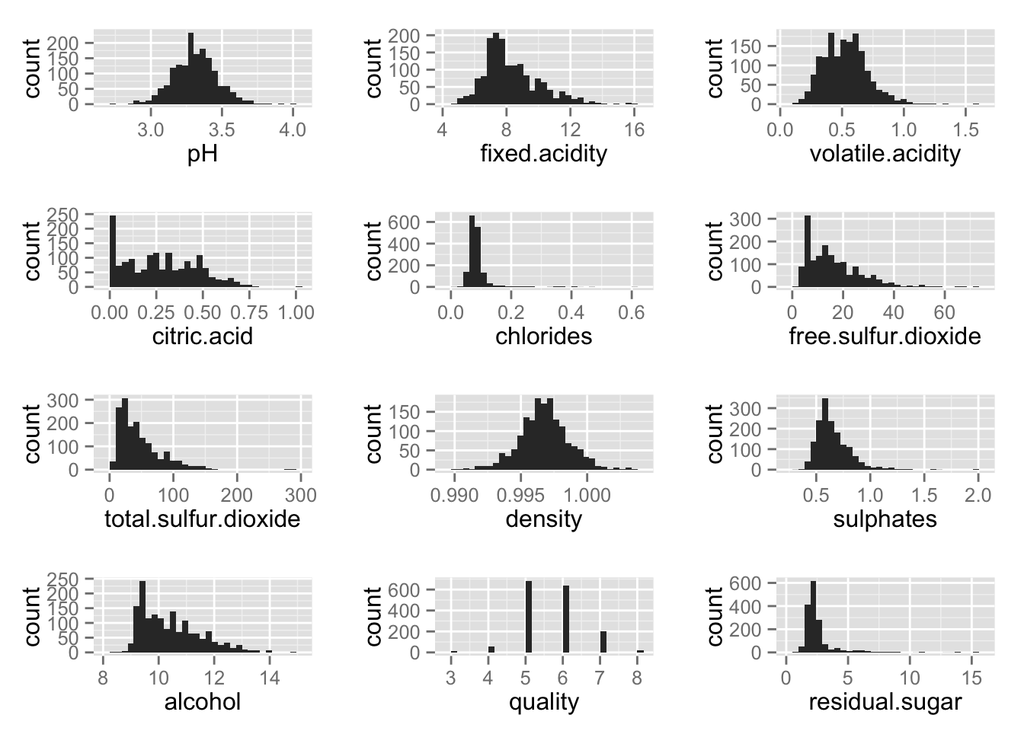

```
##        X          fixed.acidity   volatile.acidity  citric.acid
##  Min.   :   1.0   Min.   : 4.60   Min.   :0.1200   Min.   :0.000
##  1st Qu.: 400.5   1st Qu.: 7.10   1st Qu.:0.3900   1st Qu.:0.090
##  Median : 800.0   Median : 7.90   Median :0.5200   Median :0.260
##  Mean   : 800.0   Mean   : 8.32   Mean   :0.5278   Mean   :0.271
##  3rd Qu.:1199.5   3rd Qu.: 9.20   3rd Qu.:0.6400   3rd Qu.:0.420
##  Max.   :1599.0   Max.   :15.90   Max.   :1.5800   Max.   :1.000
##  residual.sugar     chlorides       free.sulfur.dioxide
##  Min.   : 0.900   Min.   :0.01200   Min.   : 1.00
##  1st Qu.: 1.900   1st Qu.:0.07000   1st Qu.: 7.00
##  Median : 2.200   Median :0.07900   Median :14.00
##  Mean   : 2.539   Mean   :0.08747   Mean   :15.87
##  3rd Qu.: 2.600   3rd Qu.:0.09000   3rd Qu.:21.00
##  Max.   :15.500   Max.   :0.61100   Max.   :72.00
##  total.sulfur.dioxide    density             pH          sulphates
##  Min.   :  6.00       Min.   :0.9901   Min.   :2.740   Min.   :0.3300
##  1st Qu.: 22.00       1st Qu.:0.9956   1st Qu.:3.210   1st Qu.:0.5500
##  Median : 38.00       Median :0.9968   Median :3.310   Median :0.6200
##  Mean   : 46.47       Mean   :0.9967   Mean   :3.311   Mean   :0.6581
##  3rd Qu.: 62.00       3rd Qu.:0.9978   3rd Qu.:3.400   3rd Qu.:0.7300
##  Max.   :289.00       Max.   :1.0037   Max.   :4.010   Max.   :2.0000
##     alcohol         quality
##  Min.   : 8.40   Min.   :3.000
##  1st Qu.: 9.50   1st Qu.:5.000
##  Median :10.20   Median :6.000
##  Mean   :10.42   Mean   :5.636
##  3rd Qu.:11.10   3rd Qu.:6.000
##  Max.   :14.90   Max.   :8.000
```

# Univariate Analysis

### What is the structure of your dataset?

Very tidy dataset with only numerical variables, all of which floats with only the quality being integers.

### What is/are the main feature(s) of interest in your dataset?

Based on the distributions in the summary it seems that volatile acidicty, citric acid, sulphates and alcohol hold large degrees of variance and could therefore have large parts to play in explaining the quality as assessed by the experts. Sugar and chlorides seem to be very concentrated around their main values with a few outliers. These could explain a few outliers in quality, but judging from the description of the datafile could also have to do with certain types of wine. For example sweet desert wines would have high sugar ratings but this would not detriment their quality.

### What other features in the dataset do you think will help support your investigation into your feature(s) of interest?

Intuitively we would assume that fixed acidity and volatile acidity (and maybe citric acid) would be very related and may have high underlying correlations, skewing any results if we would put them together in a model. The same goes for total sulfur dioxide and free sulfur dioxide.

### Did you create any new variables from existing variables in the dataset?

Upon testing the underlying correlations between the aforementioned features via the cor.test function we find that fixed acidity, citric acid and volatile acidity have high correlations. As does density with fixed acidity. Same goes for free sulfur dioxide with total sulfur dioxide. pH also shows high correlation with acidities - which in hindsight seems kind of obvious.

Because of these high underlying correlations there is an extremely high risk of multicollinearity. As such we can decide to exclude them (and lose any explanatory power that they have), roll them up with a simple multifacation/division/addition/substraction which would solve the problem slightly but not as much as we can. To prevent any multicollinearity and at the same time maintain all the explanatory power in the variables we have opted to do a factor analysis. As we are only working with numerical variables we have chosen for a principal components analysis with a varimax rotation. Analyzing the eigen values produced we derive that 4 factors would be the optimal choice in terms of explanatory power and reduction of the variables. Running the correlation test again on the variable shows that the factors hold larger correlations with the independent variable and less with eachother - mission succeeded.

```r
#install.packages('psych')
#install.packages('nFactors')
#install.packages('GPArotation')
library(nFactors)
library(psych)
library(GPArotation)

principal.test <-principal(subset(wine,select=-c(X,quality)), nfactors = 4, residuals = FALSE,rotate="varimax",n.obs=NA, covar=FALSE,scores=TRUE,missing=FALSE,impute="median",oblique.scores=TRUE,method="regression")
print(principal.test,cutoff=.3, sort=TRUE)
```

```
## Principal Components Analysis
## Call: principal(r = subset(wine, select = -c(X, quality)), nfactors = 4,
##     residuals = FALSE, rotate = "varimax", n.obs = NA, covar = FALSE,
##     scores = TRUE, missing = FALSE, impute = "median", oblique.scores = TRUE,
##     method = "regression")
## Standardized loadings (pattern matrix) based upon correlation matrix
##                      item   RC1   RC2   RC3   RC4   h2   u2
## fixed.acidity           1  0.91 -0.13  0.07  0.02 0.85 0.15
## density                 8  0.78  0.10 -0.44  0.01 0.80 0.20
## citric.acid             3  0.75  0.04  0.44  0.23 0.81 0.19
## pH                      9 -0.73  0.01 -0.01 -0.25 0.60 0.40
## free.sulfur.dioxide     6 -0.14  0.88  0.03  0.07 0.80 0.20
## total.sulfur.dioxide    7 -0.02  0.88 -0.11  0.09 0.79 0.21
## residual.sugar          4  0.35  0.46 -0.03 -0.25 0.39 0.61
## alcohol                11 -0.23 -0.11  0.78 -0.13 0.69 0.31
## volatile.acidity        2 -0.34 -0.02 -0.72 -0.13 0.64 0.36
## chlorides               5  0.13  0.00 -0.27  0.80 0.73 0.27
## sulphates              10  0.15  0.06  0.27  0.76 0.68 0.32
##
##                        RC1  RC2  RC3  RC4
## SS loadings           2.87 1.80 1.67 1.44
## Proportion Var        0.26 0.16 0.15 0.13
## Cumulative Var        0.26 0.42 0.58 0.71
## Proportion Explained  0.37 0.23 0.21 0.19
## Cumulative Proportion 0.37 0.60 0.81 1.00
##
## Test of the hypothesis that 4 components are sufficient.
##
## The degrees of freedom for the null model are  55  and the objective function was  5.03 0.3
## The degrees of freedom for the model are 17  and the objective function was  2.15
##  0.3The total number of observations was  1599  with MLE Chi Square =  3417.68  with prob <  0
##  0.3
## Fit based upon off diagonal values = 0.89
```

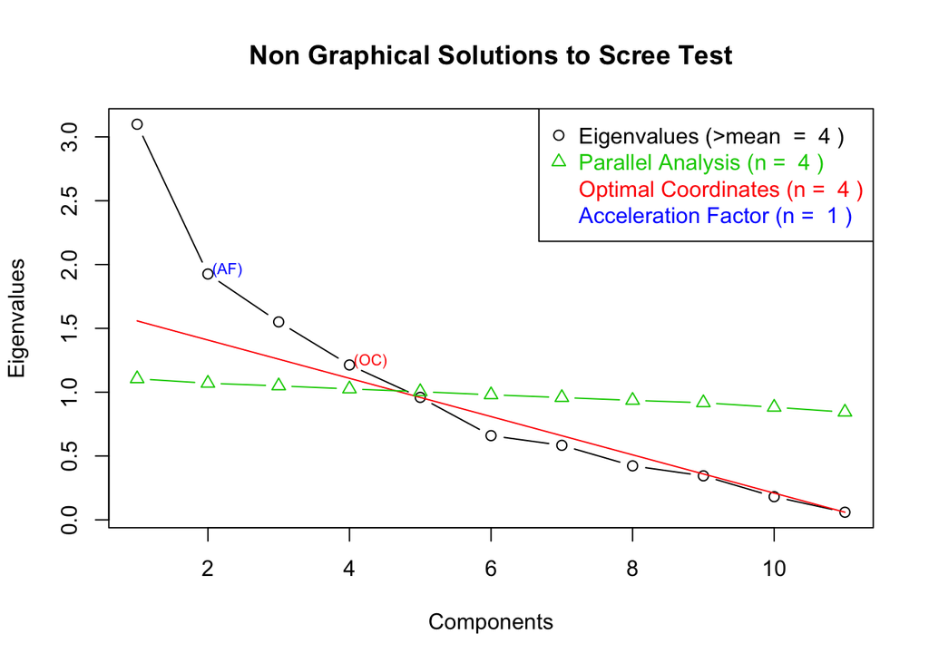

```r
ev <- eigen(cor(subset(wine,select=-c(X,quality))))
ap <- parallel(subject=nrow(subset(wine,select=-c(X,quality))),var=ncol(subset(wine,select=-c(X,quality))),
  rep=100,cent=.05)
nS <- nScree(x=ev$values, aparallel=ap$eigen$qevpea)
plotnScree(nS)
```

```r
wine.new <- wine$quality
```

[output not shown]

```
##             quality       factor1       factor2       factor3
## quality  1.00000000  5.812723e-02 -9.181474e-02  5.568688e-01
## factor1  0.05812723  1.000000e+00  5.918444e-16 -3.927899e-16
## factor2 -0.09181474  5.918444e-16  1.000000e+00 -3.962221e-16
## factor3  0.55686880 -3.927899e-16 -3.962221e-16  1.000000e+00
## factor4  0.03537147 -4.714482e-16 -1.202620e-15  2.510084e-16
##               factor4
## quality  3.537147e-02
## factor1 -4.714482e-16
## factor2 -1.202620e-15
## factor3  2.510084e-16
## factor4  1.000000e+00
```

The factors comprise as following: Factor1 - acidity - fixed.acidity, density, citric.acid, pH Factor2 - sulfur - free.sulfur.dioxide, total.sulfur.dioxide, residual.sugar Factor3 - alcohol - alcohol, volatile.acidity Factor4 - chemicals - chlorides, sulphates

### Of the features you investigated, were there any unusual distributions? Did you perform any operations on the data to tidy, adjust, or change the form of the data? If so, why did you do this?

# Bivariate Plots Section

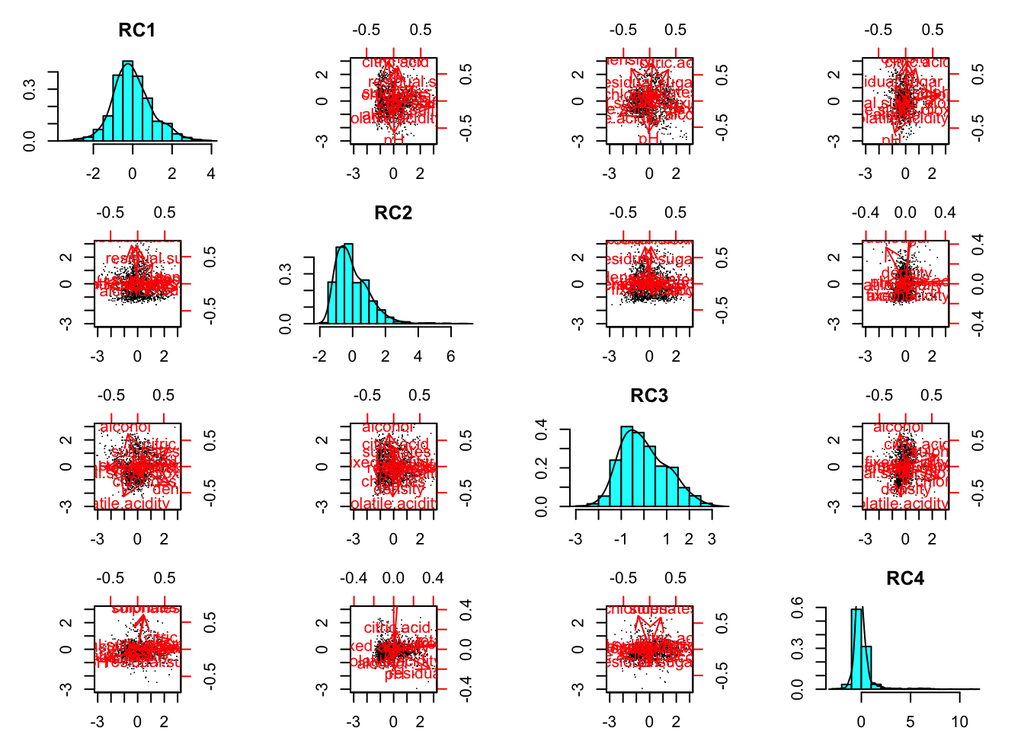

```
## Principal Components Analysis
## Call: principal(r = subset(wine, select = -c(X, quality)), nfactors = 4,
##     residuals = FALSE, rotate = "varimax", n.obs = NA, covar = FALSE,
##     scores = TRUE, missing = FALSE, impute = "median", oblique.scores = TRUE,
##     method = "regression")
## Standardized loadings (pattern matrix) based upon correlation matrix
##                      item   RC1   RC2   RC3   RC4   h2   u2
## fixed.acidity           1  0.91 -0.13  0.07  0.02 0.85 0.15
## density                 8  0.78  0.10 -0.44  0.01 0.80 0.20
## citric.acid             3  0.75  0.04  0.44  0.23 0.81 0.19
## pH                      9 -0.73  0.01 -0.01 -0.25 0.60 0.40
## free.sulfur.dioxide     6 -0.14  0.88  0.03  0.07 0.80 0.20
## total.sulfur.dioxide    7 -0.02  0.88 -0.11  0.09 0.79 0.21
## residual.sugar          4  0.35  0.46 -0.03 -0.25 0.39 0.61
## alcohol                11 -0.23 -0.11  0.78 -0.13 0.69 0.31
## volatile.acidity        2 -0.34 -0.02 -0.72 -0.13 0.64 0.36
## chlorides               5  0.13  0.00 -0.27  0.80 0.73 0.27
## sulphates              10  0.15  0.06  0.27  0.76 0.68 0.32
##
##                        RC1  RC2  RC3  RC4
## SS loadings           2.87 1.80 1.67 1.44
## Proportion Var        0.26 0.16 0.15 0.13
## Cumulative Var        0.26 0.42 0.58 0.71
## Proportion Explained  0.37 0.23 0.21 0.19
## Cumulative Proportion 0.37 0.60 0.81 1.00
##
## Test of the hypothesis that 4 components are sufficient.
##
## The degrees of freedom for the null model are  55  and the objective function was  5.03 0.3
## The degrees of freedom for the model are 17  and the objective function was  2.15
##  0.3The total number of observations was  1599  with MLE Chi Square =  3417.68  with prob <  0
##  0.3
## Fit based upon off diagonal values = 0.89
```

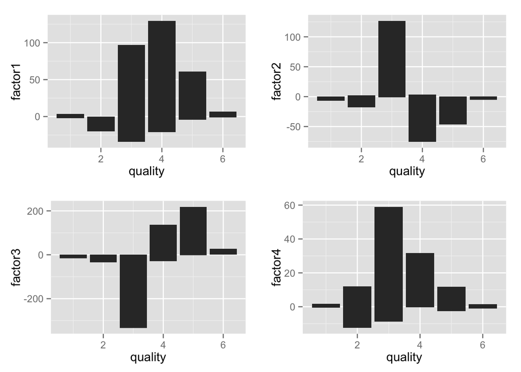

# Bivariate Analysis

### Talk about some of the relationships you observed in this part of the investigation. How did the feature(s) of interest vary with other features in the dataset?

# Multivariate Plots Section

[output not shown]

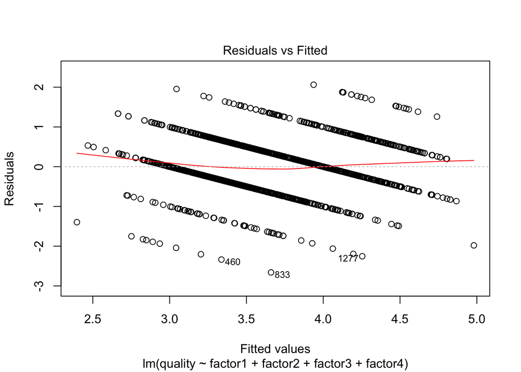

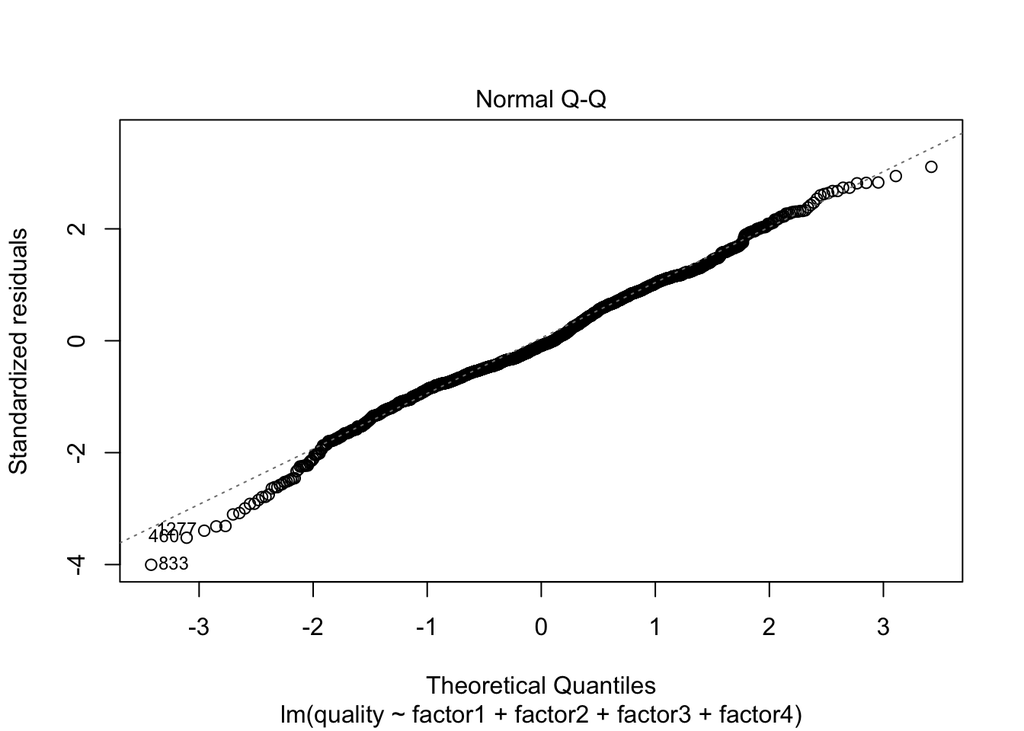

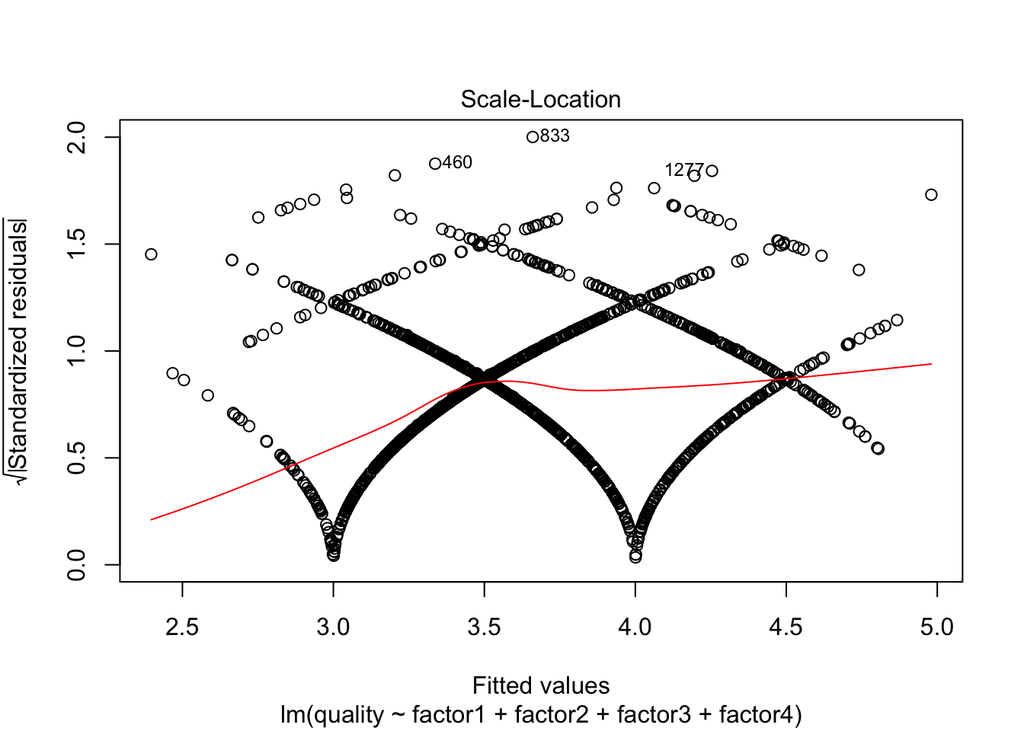

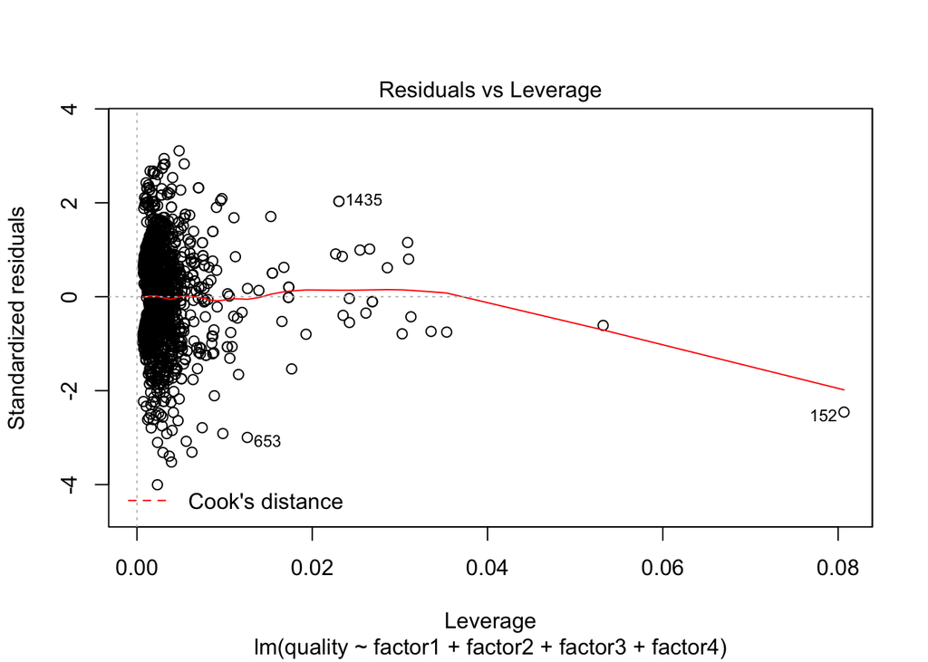

# Multivariate Analysis

In the plots of the residuals, the normal Q-Q plot and cook’s distance are all within acceptable limits. Whether the model can be used to predict quality of wines purely on their chemical compounds remains to be seen as I am sure there are aspects of personal preference involved, maybe fashionable aspects as well (some years might favour more acidic wines for example), but to explain the variance in the existing dataset I am quite happy.

# Reflection

This has been by FAAAAAR my favourite chapter in the Data Analyst Nanodegree, which may have been the cause of me going a little bit overboard on this assignment. Where as the other lessons were interesting to learn this was the part where I first saw everything coming together. Through this assignment I have learned to see below the surface of a dataset and appreciate/investigate the unusual nuances.

# Appendix

[output not shown]

```
##
## Call:
## lm(formula = quality ~ alcohol + sulphates + volatile.acidity +
##     citric.acid, data = wine)
##
## Residuals:
##      Min       1Q   Median       3Q      Max
## -2.71408 -0.38590 -0.06402  0.46657  2.20393
##
## Coefficients:
##                  Estimate Std. Error t value Pr(>|t|)
## (Intercept)       0.64592    0.20106   3.213  0.00134 **
## alcohol           0.30908    0.01581  19.553  < 2e-16 ***
## sulphates         0.69552    0.10311   6.746 2.12e-11 ***
## volatile.acidity -1.26506    0.11266 -11.229  < 2e-16 ***
## citric.acid      -0.07913    0.10381  -0.762  0.44605
## ---
## Signif. codes:  0 '***' 0.001 '**' 0.01 '*' 0.05 '.' 0.1 ' ' 1
##
## Residual standard error: 0.6588 on 1594 degrees of freedom
## Multiple R-squared:  0.3361, Adjusted R-squared:  0.3345
## F-statistic: 201.8 on 4 and 1594 DF,  p-value: < 2.2e-16
```